# Storytelling with Data and Visualizations

ICE Detention Trends - Statistical Analysis and Visualization

Hannah Rozenbaum | Project 2

## Introduction

[figure not shown]

- ICE - United States Immigration and Customs Enforcement
- This data, taken from Kaggle, displays data on ICE detention populations, with 6224 observations.
- This code analyzes the detention trends using summary statistics and visualizations to reveal insights about the population trends over time.

## About The Data

- The data is taken from a website called Kaggle, an online platform for data science and machine learning.
- Kaggle has 714,560 datasets available to the public.
- The dataset used in this project is called “ICE Detention Trends” and contains data on the daily population of ICE detention centers, as well as the number of book-ins and book-outs ranging from 2008 to 2025.

[figure not shown]

## Import Libraries

We import the ggplot2 library to create a plot for this presentation.

```r
library(ggplot2)
```

## Read the data files

We read in the csv file downloaded from Kaggle’s website, converting it into a data frame for efficient analysis.

```r
df <- read.csv("ICE_Detention_Trends.csv")
```

A peak into the contents of the dataset.

- 6224 observations
- 5 variables: date, daily_pop, midnight_pop, book_in, and book_out.

```r
head(df, n = 5)
```

```
        date daily_pop midnight_pop book_in book_out
1 2008-10-01     33876        32589    1306     1287
2 2008-10-02     33961        32475    1372     1486
3 2008-10-03     33762        32036    1287     1726
4 2008-10-04     32440        32024     404      416
5 2008-10-05     32299        32241     275       58
```

## Summary Statistics

I found that:

- Average daily population exceeds 34,000 individuals.
- There are over 5.8 million movements for both booking in and out each.
- There is a slight positive daily net change of 4.99, indicating growth in the detention population over time.

```r
# Calculate specific stats from your columns
avg_pop <- mean(df$daily_pop, na.rm = TRUE)
total_book_ins <- sum(df$book_in, na.rm = TRUE)
total_book_outs <- sum(df$book_out, na.rm = TRUE)

# Create a new column for net change
df$net_change <- df$book_in - df$book_out

# Calculate the average net change per day
avg_net_change <- mean(df$net_change, na.rm = TRUE)

print(paste("Average Daily Population:", round(avg_pop, 2)))
```

```
[1] "Average Daily Population: 34764.51"
```

```r
print(paste("Total Book-ins Recorded:", total_book_ins))
```

```
[1] "Total Book-ins Recorded: 5846656"
```

```r
print(paste("Total Book-outs Recorded:", total_book_outs))
```

```
[1] "Total Book-outs Recorded: 5815626"
```

```r
print(paste("Average net change in ICE detention population per day:", round(avg_net_change, 2)))
```

```
[1] "Average net change in ICE detention population per day: 4.99"
```

## Visualiazing the Trends over Time

- The line plot below shows the daily population of ICE detention centers over time, with the x-axis formatted to display years for better readability, ranging from 2008 to 2025.
- This plot displays large spikes and declines, potentially reflecting policy changes and external factors influencing detention.

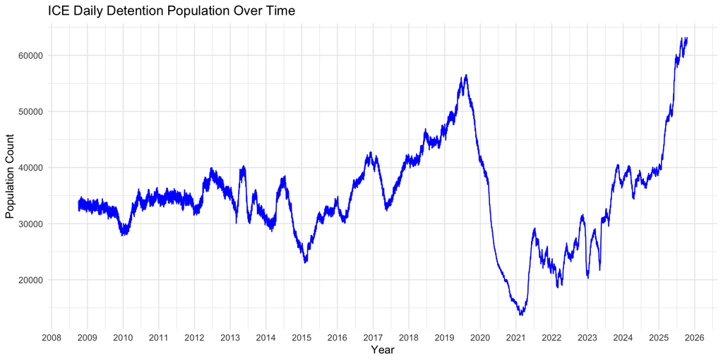

```r
# Convert the text column to a date object, so ggplot can understand the timeline and create x-axis labels.
df$date <- as.Date(df$date)

# Plot with Scale Formatting
ggplot(df, aes(x = date, y = daily_pop, group = 1)) +
  geom_line(color = "blue") +
  # Date formatting for the x-axis
  scale_x_date(date_labels = "%Y", date_breaks = "1 year") +
  theme_minimal() +
  labs(
    # Plot and axis labels
    title = "ICE Daily Detention Population Over Time",
    x = "Year",
    y = "Population Count"
  )
```

## Plot

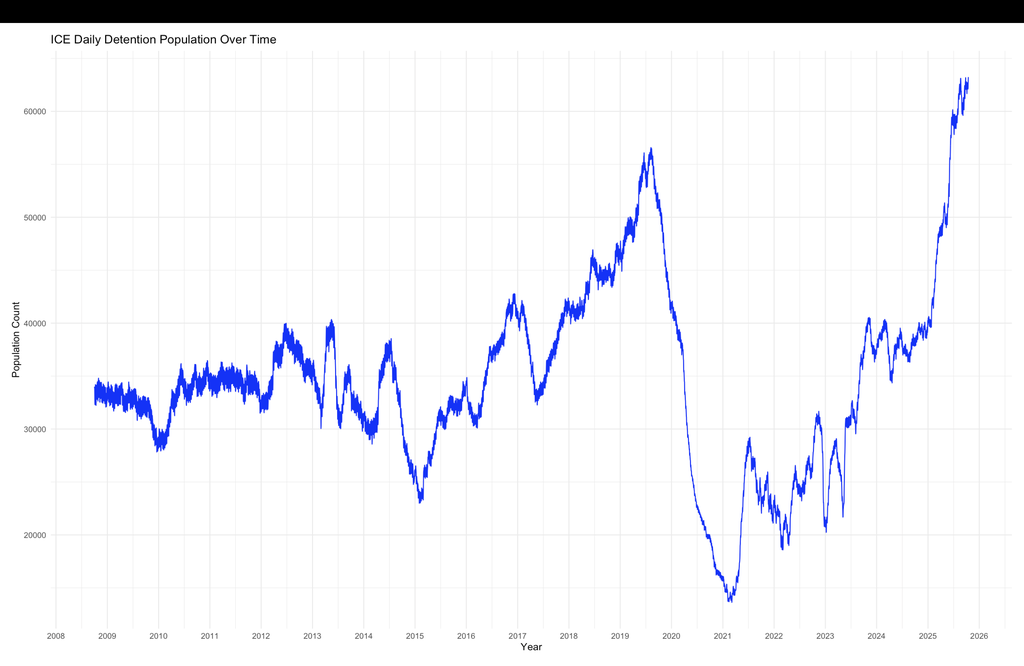

## Conclusions

- Visual analysis conveys that detention is not static but follows trends, suggesting influence from outside factors.
- We can use R to quickly analyze large datasets, with this one containing over 5,000 records with 5 columns.